# **Tugas Hands On 2**

#### Nama : Marsella Yesi Natalia Sinaga

#### NIM : 121140174

### **Sistem/Teknologi Multimedia**

## **SOAL 1**

Dengan foto anda sendiri, lakukanlah eksperimen berikut ini. Editlah sebuah foto yang terdapat wajah anda, namun kali ini tidak dengan photoshop, melainkan dengan python. Lakukan penyesuaian berikut ini.

- Lakukan resize untuk foto anda menjadi 1080 pada dimension terpanjangnya. Gunakan cv2.resize untuk melakukan resize.
- Buatlah frame berwarna kuning (RGB value: 255, 255, 0) sebesar 25 pixel + dua digit terakhir NIM anda pada setiap sisi foto anda. Frame tersebut akan mengelilingi foto setebal 25 pixel + dua digit terakhir NIM anda.
- Aturlah intensitas warna pada channel merah di bagian tengah (50 - 150), dan naikkan sebesar 20 poin
- Turunkanlah intensitas warna pada channel biru di atas (200- 250), dan turunkan sebesar 20 poin
- Tampilkanlah histogram dari foto tersebut
- Jelaskan hasil eksperimen anda

#### **Import Library**

```python
import numpy as np
import matplotlib.pyplot as plt
import cv2 # opencv
import os
```

#### **Membaca Gambar**

```python
path_img = os.path.join(os.getcwd(), 'data', 'marsella.jpeg')

# mengecek apakah file gambar ada
# jika tidak ada, akan tercetak pesan "File tidak ditemukan: <path>"
if not os.path.exists(path_img):
    print('File tidak ditemukan:', path_img)
    exit()
```

#### **Loading Gambar**

```python
img = cv2.imread(path_img)
```

#### **Ubah Gambar BGR ke RGB**

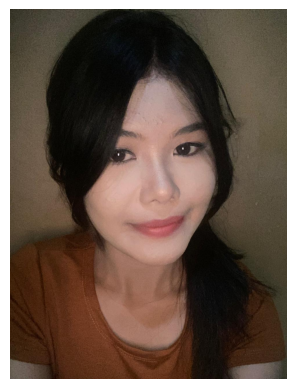

```python
# Mengubah gambar bgr ke rgb
img = cv2.imread(path_img) # masih dalam format BGR
img = cv2.cvtColor(img, cv2.COLOR_BGR2RGB) # konversi ke format RGB

# Menampilkan gambar
plt.axis ('off')
plt.imshow(img)
plt.show()
```

#### **Resize Gambar**

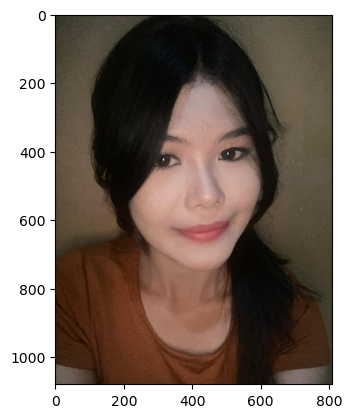

```python
# Menghitung rasio untuk resize
height, width = img.shape[:2]
if height > width:
    new_height = 1080
    new_width = int((1080 / height) * width)
else:
    new_width = 1080
    new_height = int((1080 / width) * height)

# Resize foto
resized_img = cv2.resize(img, (new_width, new_height))
plt.imshow(resized_img)
plt.show()
```

#### **Membuat Frame**

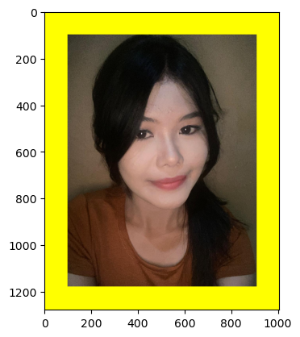

```python
# Menghitung dimensi bingkai
frame_thickness = 25 + 74
yellow_frame = np.zeros((resized_img.shape[0] + frame_thickness * 2, resized_img.shape[1] + frame_thickness * 2, 3), dtype=np.uint8)
yellow_frame[:] = (255, 255, 0)

# Menempatkan gambar di tengah bingkai
yellow_frame[frame_thickness:frame_thickness + resized_img.shape[0], frame_thickness:frame_thickness + resized_img.shape[1]] = resized_img
plt.imshow(yellow_frame)
plt.show()
```

#### **Mengatur Intensitas Warna**

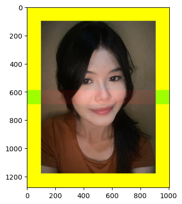

```python
# Naikkan channel merah di bagian tengah (50-150)
yellow_frame[frame_thickness:frame_thickness + resized_img.shape[0], frame_thickness:frame_thickness + resized_img.shape[1]] = resized_img
middle_row_start = yellow_frame.shape[0] // 2 - 50
middle_row_end = yellow_frame.shape[0] // 2 + 50

# Menaikkan intensitas channel merah sebesar 20 poin
yellow_frame[middle_row_start:middle_row_end, :, 0] = np.clip(
    yellow_frame[middle_row_start:middle_row_end, :, 0] + 20, 0, 255
)
plt.imshow(yellow_frame)
plt.show()
```

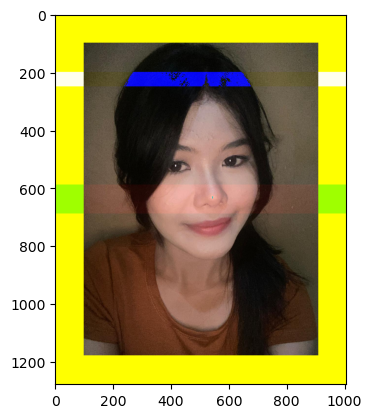

```python
# Turunkan intensitas channel biru di bagian atas (200-250)
blue_row_start = 200
blue_row_end = 250

# Menurunkan intensitas channel biru sebesar 20 poin
yellow_frame[blue_row_start:blue_row_end, :, 2] = np.clip(
    yellow_frame[blue_row_start:blue_row_end, :, 2] - 20, 0, 255
)
plt.imshow(yellow_frame)
plt.show()
```

#### **Tampilan Histogram**

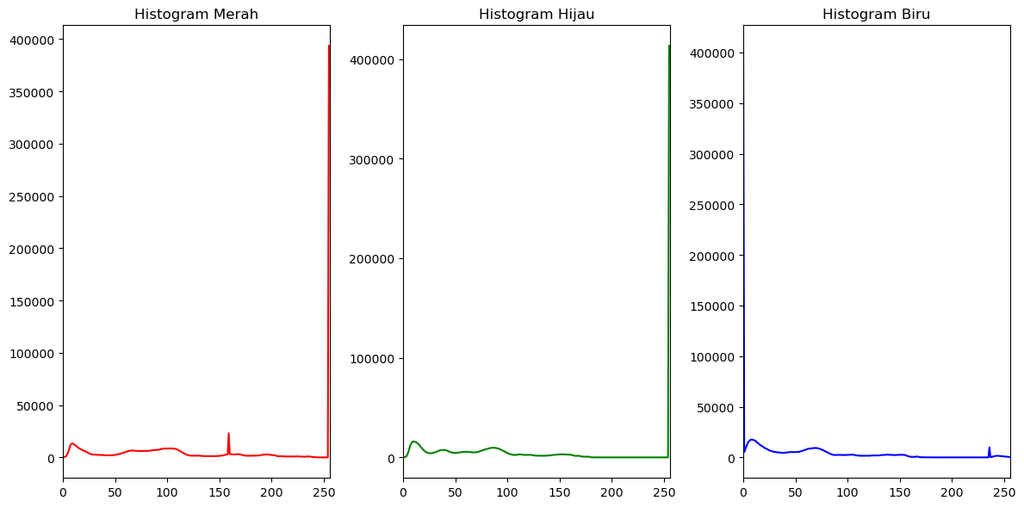

```python
# Menampilkan histogram dari gambar yang telah dimodifikasi
plt.figure(figsize=(12, 6))

# Menampilkan Histogram
red_hist, bins = np.histogram(yellow_frame[:, :, 0].ravel(), bins=256, range=[0, 256])
plt.subplot(1, 3, 1)
plt.plot(bins[:-1], red_hist, color='red')
plt.xlim([0, 256])
plt.title('Histogram Merah')

# Histogram untuk channel hijau
green_hist, bins = np.histogram(yellow_frame[:, :, 1].ravel(), bins=256, range=[0, 256])
plt.subplot(1, 3, 2)
plt.plot(bins[:-1], green_hist, color='green')
plt.xlim([0, 256])
plt.title('Histogram Hijau')

# Histogram untuk channel biru
blue_hist, bins = np.histogram(yellow_frame[:, :, 2].ravel(), bins=256, range=[0, 256])
plt.subplot(1, 3, 3)
plt.plot(bins[:-1], blue_hist, color='blue')
plt.xlim([0, 256])
plt.title('Histogram Biru')

plt.tight_layout()
plt.show()
```

## **SOAL 2**

Dengan foto anda sendiri, lakukanlah eksperimen berikut ini

- Convert image dari RGB menjadi Grayscale
- Tampilkan histogram dari foto tersebut
- Lakukanlah normalisasi level intensitas warna pada foto tersebut. Aturlah agar intensitas warna terendah menjadi 0, dan intensitas warna tertinggi menjadi 255
- Tampilkan histogram dari hasil normalisasi
- Buatlah pixel-art dari foto tersebut. Caranya adalah dengan mengubah intensitas warna menjadi 0 atau 255. Jika intensitas warna < 128, maka ubah menjadi 0, dan jika intensitas warna >= 128, maka ubah menjadi 255. Tunjukkan hasilnya

#### **Convert Image dari RGB menjadi Grayscale**

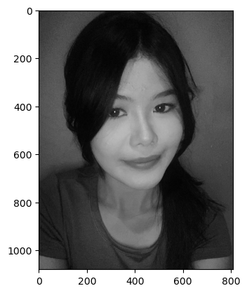

```python
gray_img = cv2.cvtColor(resized_img, cv2.COLOR_BGR2GRAY)
plt.imshow(gray_img, cmap='gray')
plt.show()
```

#### **Tampilan Histogram**

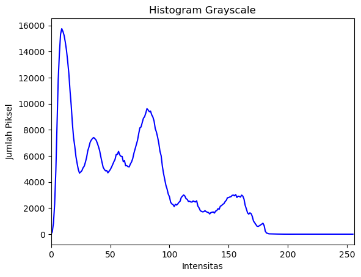

```python
# Hitung histogram
hist_gray = cv2.calcHist([gray_img], [0], None, [256], [0, 256])

# Tampilkan histogram
plt.plot(hist_gray, color='blue')
plt.xlim([0, 256])
plt.title("Histogram Grayscale")
plt.xlabel("Intensitas")
plt.ylabel("Jumlah Piksel")
plt.show()
```

#### **Normalisasi level intensitas warna**

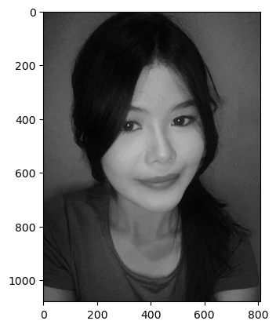

```python
# Normalisasi level intensitas
min_val = np.min(gray_img)
max_val = np.max(gray_img)
normalized_img = (gray_img - min_val) * (255 / (max_val - min_val))
normalized_img = normalized_img.astype(np.uint8)
plt.imshow(normalized_img, cmap='gray')
plt.show()
```

#### **Tampilan Histogram dari Hasil Normalisasi**

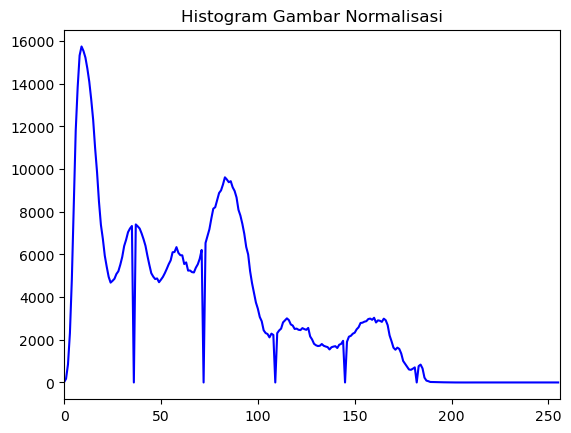

```python
# Hitung histogram untuk gambar yang dinormalisasi
hist_normalized = cv2.calcHist([normalized_img], [0], None, [256], [0, 256])

# Tampilkan histogram
plt.plot(hist_normalized, color='blue')
plt.xlim([0, 256])
plt.title("Histogram Gambar Normalisasi")
plt.show()
```

#### **Membuat Pixel-Art**

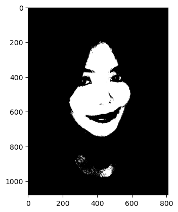

```python
# Ubah intensitas warna menjadi 0 atau 255
pixel_art_img = np.where(normalized_img < 128, 0, 255).astype(np.uint8)
plt.imshow(pixel_art_img, cmap='gray')
plt.show()
```

## **SOAL 3**

Dengan foto anda sendiri, lakukanlah eksperimen berikut ini

- Naikkan kecerahan (brightnes) pada foto tersebut. Anda tidak boleh menggunakan library cv2 untuk menaikkan kecerahan. Anda hanya boleh menggunakan operasi matriks. Jelaskan langkah-langkah yang anda lakukan. Tampilkan histogram dari foto tersebut
- Turunkan saturasi warna pada foto tersebut. Anda tidak boleh menggunakan library cv2 untuk menurunkan saturasi warna. Anda hanya boleh menggunakan operasi matriks. Jelaskan langkah-langkah yang anda lakukan. Tampilkan histogram dari foto tersebut
- Turunkan kontras pada foto tersebut. Anda tidak boleh menggunakan library cv2 untuk menurunkan kontras. Anda hanya boleh menggunakan operasi matriks. Jelaskan langkah-langkah yang anda lakukan. Tampilkan histogram dari foto tersebut

#### **Membaca Gambar**

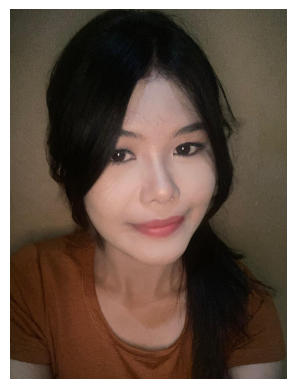

```python
path_img = os.path.join(os.getcwd(), 'data', 'marsella.jpeg')

# mengecek apakah file gambar ada
# jika tidak ada, akan tercetak pesan "File tidak ditemukan: <path>"
if not os.path.exists(path_img):
    print('File tidak ditemukan:', path_img)
    exit()
img = plt.imread(path_img)

# Menampilkan gambar
plt.axis ('off')
plt.imshow(img)
plt.show()
```

#### **Menaikkan Kecerahan (Brightnes)**

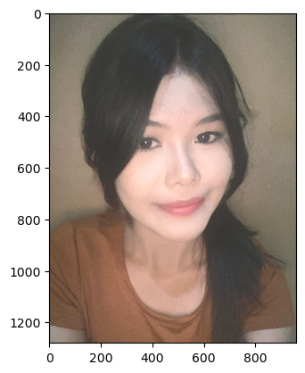

```python
# Manipulasi Gambar ke format Float
img = img.astype(np.float32)

# Menaikkan kecerahan
brightness_increase = 50
brightened_img = np.clip(img + brightness_increase, 0, 255)
plt.imshow(brightened_img.astype(np.uint8))
plt.show()
```

### **Penjelasan:**

##### Manipulasi Gambar ke format Float

1. Untuk mengonversi tipe data gambar dari format integer ke format float32. karna Operasi aritmatika dalam penambahan kecerahan, dapat menghasilkan nilai yang lebih besar dari 255 (nilai maksimum untuk uint8). Jika tidak mengonversi ke float, penambahan ini dapat menyebabkan overflow (nilai yang melebihi batas maksimum) dan menghasilkan artefak yang tidak diinginkan. Dengan menggunakan float32, maka dapat menangani nilai yang lebih besar tanpa kehilangan informasi. untuk hasil Gambar sekarang berada dalam format float, dengan nilai pixel yang dapat berkisar dari 0 hingga lebih dari 255.

##### Menaikkan kecerahan

2. - img + brightness_increase: untuk menambahkan nilai brightness_increase (50) ke setiap pixel dalam gambar. Ini berarti setiap pixel akan menjadi lebih terang dengan nilai 50.
   - np.clip(..., 0, 255): Fungsi np.clip digunakan untuk membatasi nilai pixel agar tetap dalam rentang 0 hingga 255. Jika hasil penambahan kecerahan melebihi 255, maka nilai tersebut akan dipotong menjadi 255. Jika ada nilai yang kurang dari 0 (meskipun dalam konteks ini tidak mungkin karena sudah menggunakan float), maka nilai tersebut akan dipotong menjadi 0.
   - gambar yang telah ditingkatkan kecerahannya, dengan semua nilai pixel yang berada dalam rentang yang valid (0-255).

#### **Tampilan Histogram**

[figure not shown]

```python
# Menampilkan histogram
plt.figure(figsize=(12, 6))
plt.subplot(1, 2, 2)
plt.plot(hist_normalized, color='blue')
plt.title('Histogram gambar setelah diberi brightnes')
plt.xlim([0, 256])
plt.show()
```

#### **Menurunkan Saturasi Warna**

```
<function matplotlib.pyplot.show(close=None, block=None)>
```

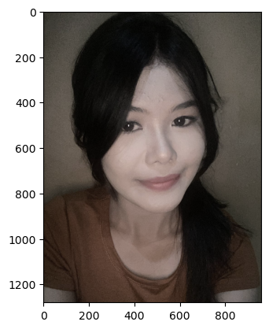

```python
# Menghitung gambar grayscale dengan mengambil rata-rata dari R, G, B
gray_image = np.mean(img, axis=2, keepdims=True).astype(np.uint8)

# Menentukan faktor pengurangan saturasi
saturation_factor = 0.5

# Mengurangi saturasi dengan mencampur gambar grayscale dengan gambar asli
desaturated_image = (img * saturation_factor + gray_image * (1 - saturation_factor)).astype(np.uint8)
plt.imshow(desaturated_image)
plt.show
```

#### **Penjelasan** :

- pertama menghitung gambar grayscale dengan mengambil rata-rata nilai R, G, dan B setiap piksel menggunakan fungsi np.mean(img, axis=2, keepdims=True), yang menghasilkan matriks grayscale berukuran (tinggi, lebar, 1).
- Selanjutnya, menetapkan faktor pengurangan saturasi sebesar 0.5, yang berarti gambar akan memiliki saturasi setengah dari saturasi aslinya.
- Kemudian, mengurangi saturasi dengan mencampurkan gambar asli yang telah dikalikan dengan faktor pengurangan saturasi dan gambar grayscale yang telah dikalikan dengan (1 - saturation_factor), menghasilkan gambar akhir desaturated_image yang memiliki warna lebih lembut.
- Terakhir, gambar hasil ini ditampilkan menggunakan plt.imshow(desaturated_image) diikuti dengan plt.show() untuk memperlihatkan efek pengurangan saturasi yang telah diterapkan.

#### **Tampilan Histogram**

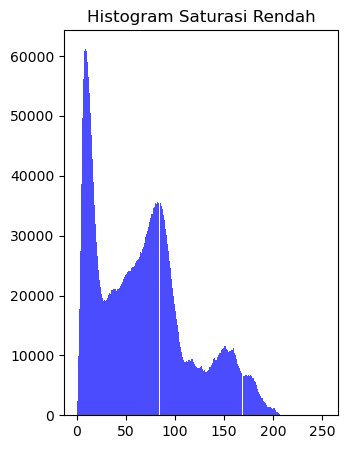

```python
# Histogram gambar yang telah dikurangi saturasinya
plt.figure(figsize=(12, 5))
plt.subplot(1, 3, 3)
plt.hist(desaturated_image.ravel(), bins=256, color='blue', alpha=0.7)
plt.title('Histogram Saturasi Rendah')
plt.show()
```

#### **Menurunkan Kontras**

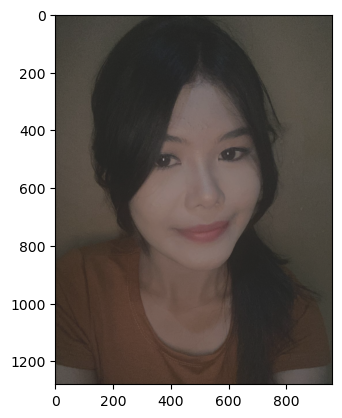

```python
# Menghitung rata-rata intensitas gambar
mean_intensity = np.mean(img)

# Menentukan faktor pengurangan kontras
contrast_factor = 0.5

# Mengurangi kontras menggunakan formula
low_contrast_image = ((img - mean_intensity) * contrast_factor + mean_intensity).astype(np.uint8)

# Membatasi nilai piksel agar tetap dalam rentang 0-255
low_contrast_image = np.clip(low_contrast_image, 0, 255)
plt.imshow(low_contrast_image)
plt.show()
```

#### **Penjelasan** :

- mean_intensity = np.mean(img) digunakan sebagai acuan untuk menurunkan kontras.
- Nilai contrast_factor = 0.5 mengatur seberapa besar kontras dikurangi—dalam hal ini, setengahnya.
- Formula ((img - mean_intensity) * contrast_factor + mean_intensity) mendekatkan intensitas tiap piksel ke rata-rata, menurunkan perbedaan intensitas di gambar, sehingga kontras berkurang.
- Setelah itu, np.clip(low_contrast_image, 0, 255) membatasi nilai piksel agar tetap dalam rentang 0-255, sehingga tidak ada distorsi akibat intensitas yang terlalu tinggi atau rendah.
- Gambar hasil dengan kontras yang sudah berkurang kemudian ditampilkan menggunakan plt.imshow(low_contrast_image) dan plt.show().

#### **Tampilan Histogram**

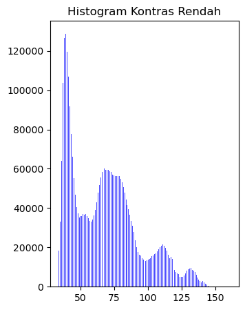

```python
# Histogram gambar yang telah dikurangi kontrasnya
plt.figure(figsize=(12, 5))
plt.subplot(1, 3, 3)
plt.hist(low_contrast_image.ravel(), bins=256, color='blue', alpha=0.7)
plt.title('Histogram Kontras Rendah')
plt.show()
```